# Investigating Trends in the Last 50 Years of Ice Coverage at the Great Lakes

# 1 Introduction

The Great Lakes of North America combine to be the largest body of fresh water in terms of surface area in the entire world, measuring about 94,250 square miles (Beeton 2024). The Great Lakes play a vital role in the climate of the central-eastern portion of North America. Their presence causes warmer winters and coolers summers in the neighboring regions. This report aims to investigate the how of ice coverage in the Great Lakes has changed annually since 1973. Ice coverage in these lakes is important because of the significant effects it (or the lack thereof) can have on the natural environment. A lack of ice coverage can lead to wetter and warmer winters with increased snowfall (Graham 2024). It also can be a detriment to natural processes of native species that reside in or near the lakes. In fact, more ice coverage present can cool the water, causing a decrease in emissions of nitrous oxide.

With these consequences in mind, investigation on the trend of ice coverage presence in the Great Lakes is of utmost importance. As previously alluded to, this report utilizes a data set containing the percent of the Great Lakes’ surface area covered by ice at the daily level since 1973 to formulate an answer about annual ice coverage patterns in the Great Lakes.

# 2 Methods

## 2.1 Data

To deal with the shear volume of missing data, we decide to impute this data based on the underlying trends leading up to recorded data and trailing after recorded data. We feel this is appropriate for two reasons: it is unlikely that the first recorded observation is significantly greater than zero, meaning that there may have been ice cover leading up to that day but the data was not collected. This is especially true in the earlier years where we see that magically there was an increase from zero ice cover to over $10\%$ of the lakes being frozen. This may be the case that winter storms or temperature chills made data too dangerous to collect in the earlier years, and thus the recorders simply had to wait; We also assume that, in most cases, the imputed data will always converge to zero ice cover based on the increasing leading trend and the decreasing trailing trend, no matter how long it takes. Thus, it doesn’t matter that we are imputing more zeroes before or after known recorded zeroes.

To impute the data, we use auto-regressive models to forecast into the future and the past. We split each year into its own times series and fit an *autoregressive integrated moving average* (ARIMA) model to the non-missing observations and use these models to predict the future missing values. Forecasting into the past is done similarly by simply reversing the time series. We impute each missing observation as the point estimate of the forecast. We also obtain 95% confidence intervals for every forecasted value. See section 3.1 for more details. We set all negative estimates to zero, as we cannot have lower than $0\%$ ice cover. We also weight each observation by $\frac{1}{\text{CI}_U - \text{CI}_L}$, or the inverse width of the confidence interval. This means that even non-zero imputed values far away will be shrunk towards zero and not significantly impact the results. All known recorded values are given a weight of one. This weighting scheme is ideal, as it also effectively handles cases when the leading trend is decreasing - such as the case with the year 1979 (see figure 3.3) - and the imputed values go toward infinity. This weighting scheme will push these large imputed values down to zero anyway, thereby mitigating their effects on our analysis.

We convert our initial data set to a long format and merge the resulting forecasted data into this data set. The data set is organized as follows:

- `date` - the day of the year that ice coverage was recorded, from November 10 to June 5 each year.
- `year` - the year in which the ice coverage was recorded, from November 1972 to June 2024. The years are listed as the year of the winter, similar to fiscal years. So all observations occurring between November 10 to December 31 will be listed as an observation for the next year. For example, observations from November 10 to December 31, 1972 will instead be listed as 1973.
- `coverage` - The percentage of the surface area of the Great Lakes that are covered in ice on a particular day. Any missing values will be replaced by the forecasted values found in the `mean` column.
- `mean` - The point estimate for the forecasted ice coverage values, which will replace the missing values found in the `coverage` column. Any values less than zero will be set to zero.
- `Lower 95%` - The lower bound of the 95% confidence interval for the forecasts
- `Upper 95%` - The upper bound of the 95% confidence interval for the forecasts
- `weight` - The weights for each observation found in the `coverage` column, calculated as the inverse width of the confidence intervals: $\frac{1}{\text{CI}_U - \text{CI}_L}$.

## 2.2 Measuring Degree of Ice Coverage

Even with data imputation, there exists large gaps of data every year from June 6 to November 9. We also have that we are primarily interested in the general trend in ice coverage over time, rather than attempting to fit an accurate model that captures the nature of the data. As such, we prefer to use a regression approach as opposed to a time series approach to assess whether there is a significant decline in ice coverage since 1973.

The cumulative ice cover seems desirable, but is currently computed from the raw percentages of frozen lake surfaces. However, as ice coverage increases across the lakes, two things are true. There is less of the lake that can become frozen over. Also, the portions of the lake that freeze last tend to be away from the shoreline because there is more warmer (non-freezing) water underneath the coldest water (aka, pools of water freeze at the perimeter then move toward the center) (Beeton 2024). With these two points in mind, increases of ice coverage at high percentages are more *impressive* because of the less lake available to freeze and the increasing reluctance of that water to freeze in comparison to water closer to the shoreline.

These phenomena led to the development of investigating the ratio of ice coverage, rather than just the percentage. This is because ratios increase at a greater rate then percentages do at more extreme values. For example, consider two measurements of difference in ice coverage: 50% to 60% and 90% to 99%. The difference between these two is 10% and 9%, respectively. However, the difference in ratios of these measurements are $\frac{60}{40}-\frac{50}{50}=0.5$ and $\frac{99}{1}-\frac{90}{10}=90$.

Transforming the response to be log-ratios is appealing because it makes the response span the entire real line $\mathbb{R}$. But as we see in figure 2.1 **(E)**, the time series of this response shows an even more extreme downwards trend than even the mean did. This response has all of the same problems as the mean. We believe this is the case due to the amount of observations close to or equal to zero. These values will be very large negatives, and thus counteracts the effect of the emphasizing the peaks. We believe this metric is effectively capturing the *fluctuations* in weather patterns, temperatures and ice coverage, rather than the more general shape.

Given all of these considerations, we choose to model the cumulative ice cover ratios against time in years to assess whether their exists a significant declining trend in ice cover at the Great Lakes since 1973.

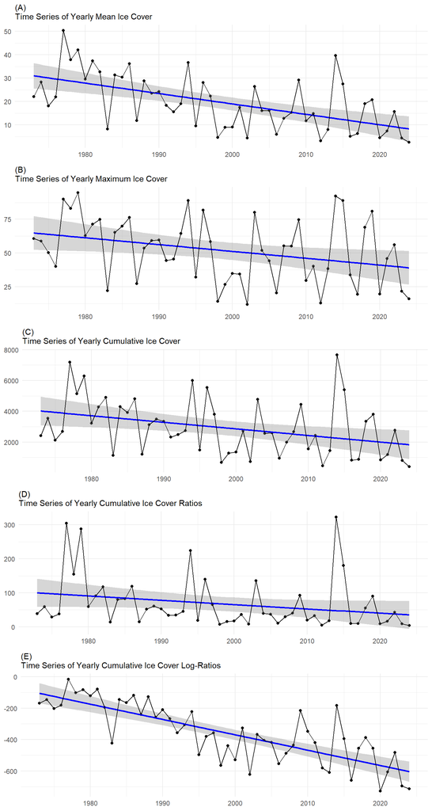

Figure 2.1: Annualizd Time Series of Candidate Metrics

## 2.3 Assessing Trend in Ice Coverage

To assess if their is a systemic change in the ice coverage from 1973 to today, we measure the general trend in the annual cumulative ice cover ratios. Measuring the trend line will answer the direction of the trend (i.e. a decreasing trend would indicate a general decrease in the ice cover of the Great Lakes) and constructing a lower and upper bound on this estimated trend line will tell us if the perceived relationship is actually significant, or just random chance from this 50 year window. We require a method that can handle time series data with only one observation per year, is robust to the distributional nature of the response variable (the distribution of the ice cover ratios can not be accurately determined), and is robust to outliers, as some years experienced far greater ice cover than others. We use the non-parametric Theil-Sen estimation to estimate the general trend over time.

The Theil-Sen estimator is a robust statistical method for estimating the slope of a linear trend in the presence of outliers or non-normal residuals (Wikipedia contributors 2024). It is particularly useful when dealing with data that may deviate from the assumptions of ordinary least squares regression. The Theil-Sen estimator calculates the slope of a line fitting a bivariate data set $(x_i, y_i)$. Unlike least squares regression, which minimizes the sum of squared residuals, the Theil-Sen estimator is based on the median of pairwise slopes, making it robust to outliers.

The Theil-Sen estimation functions as follows: For a data set with $n$ data points, we calculate the slope $m_{ij}$ between each pair of points $(x_i, y_i),\ (x_j, y_j)$ as

$$m_{ij} = \frac{y_j - y_i}{x_j - x_i} \quad \text{for all } 1 \leq i < j \leq n, \text{where } x_j \neq x_i.$$

The Theil-Sen slope $\hat{m}$ is the median of all pairwise slopes, that is $\hat{m} = \text{median}(m_{ij})$. After determining the slope $\hat{m}$, the intercept $\hat{b}$ is calculated by solving the slope-intercept form equation $b_i = y_i - \hat{m}x_i$ and then taking the median of these intercept values $\hat{b} = \text{median}(b_i)$. The resulting Theil-Sen estimated trend line is given by $y = \hat{m}x + \hat{b}$.

Confidence intervals for the slope are derived using the ranks of the sorted pairwise slopes. We simply arrange the pairwise slopes $m_{ij}$ is ascending order and take the middle 95% of these values. It is usually recommended to have around 600 pairs of points to calculate an accurate 95% interval for the pairwise slopes, which given that our annual data consists of $\binom{52}{2} = 1326$, we have more than doubled the recommended amount of pairwise slopes to estimate the confidence interval. The results of the Theil-Sen estimation can be interpreted similarly to simple linear regression.

Before we fit such a model, we must take into account that this data is time series in nature. There exists the possibility of substantial *autocorrelation* from year to year, that is the weather and ice cover of one year may attribute and bias the next year. Autocorrelation and partial autocorrelations of the cumulative ice cover ratios were assessed to judge whether significant autocorrelation exists in the response from year to year.

## 2.4 Software

For our analysis, we will be utilizing the statistical software `R` (R Core Team 2024) to conduct all data processing, exploratory data analysis (EDA), model fitting and statistical tests. We will employ several R packages to enhance our workflow and output. The `tidyverse` (Wickham et al. 2019) package will be used for data manipulation and visualization. The `forecast` (Hyndman et al. 2024) package will assist in data imputation, while the `mblm` (Komsta 2019) package will aid in conducting the Theil-Sens trend test. We will also leverage `kableExtra` (Zhu 2024) and `gridExtra` (Auguie 2017) for constructing tables and building arranging visualizations. Finally, `knitr` (Xie 2024) will assist in generating and outputting the final HTML document. In addition to `knitr`, we will also use the *robobook* theme from the `rmdformats` (Barnier 2022) package for extra form and functionality in the final report.

# 3 Results

## 3.1 Exploratory Data Analysis

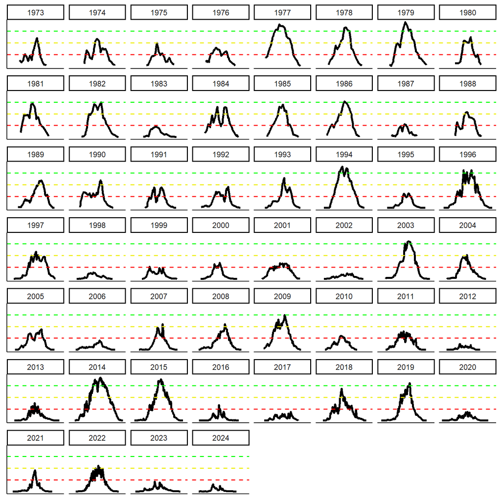

Figure 3.1: Daily Ice Cover each Year

As previously mentioned, this data contains a significant and varying amount of data from year to year. About 29% of the data set is missing, possibly resulting from many different factors in the data collection process. Every missing value is either a preceding or trailing the recorded data for its respective year. Figure 3.2 shows the amount of missing values in each of the 52 years in the data set. Evidently, there appears to be a decreasing trend in the number of missing values over time. Although it’s speculation, the larger amount of earlier missing values may be due to manual operation processes or limited technology available, possibly affecting precision, efficiency, and practicality. Technological advancements over time have likely improved data collection accuracy and consistency, reducing missing occurrences in more recent years as instruments and automated systems evolved. This evolution highlights the impact of improved technology, which may capture smaller or intermittent ice cover changes that previous manual methods did not. Thus, the earlier missing values might reflect both limitations in data collection technology and a historical practice of skipping measurements where ice cover was visually undetectable.

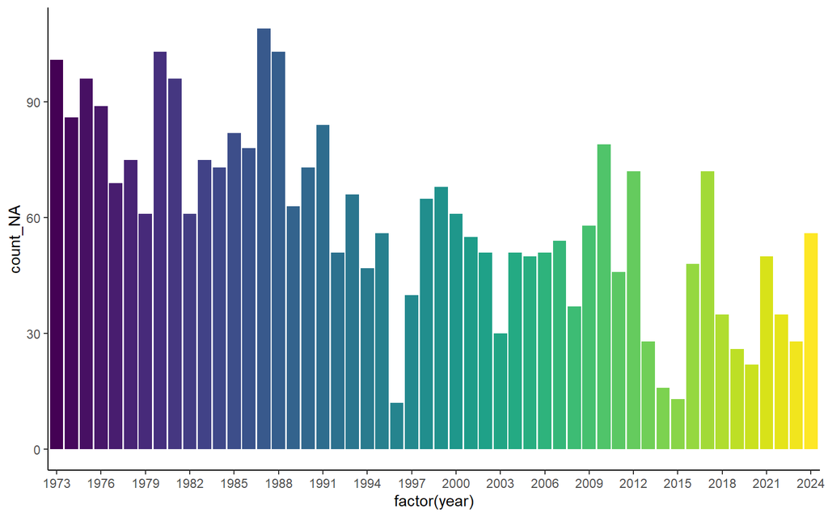

Figure 3.2: Number of Missing Values each Year

Table 3.1: Results of Augmented Dickey-Fuller Tests for Stationarity. Red means non-stationary and green means stationary.

|  | No Difference | First Difference | Second Difference |
| --- | --- | --- | --- |
| 1973 | 0.65 | 0.2 | 0.01 |
| 1974 | 0.63 | 0.09 | 0.01 |
| 1975 | 0.06 | 0.01 | 0.01 |
| 1976 | 0.69 | 0.09 | 0.01 |
| 1977 | 0.36 | 0.09 | 0.01 |
| 1978 | 0.89 | 0.02 | 0.01 |
| 1979 | 0.57 | 0.03 | 0.01 |
| 1980 | 0.14 | 0.01 | 0.01 |
| 1981 | 0.45 | 0.05 | 0.01 |
| 1982 | 0.48 | 0.02 | 0.01 |
| 1983 | 0.47 | 0.05 | 0.01 |
| 1984 | 0.52 | 0.01 | 0.01 |
| 1985 | 0.74 | 0.02 | 0.01 |
| 1986 | 0.95 | 0.13 | 0.01 |
| 1987 | 0.78 | 0.04 | 0.01 |
| 1988 | 0.17 | 0.01 | 0.01 |
| 1989 | 0.92 | 0.06 | 0.01 |
| 1990 | 0.41 | 0.09 | 0.01 |
| 1991 | 0.36 | 0.01 | 0.01 |
| 1992 | 0.68 | 0.01 | 0.01 |
| 1993 | 0.72 | 0.12 | 0.01 |
| 1994 | 0.9 | 0.03 | 0.01 |
| 1995 | 0.74 | 0.01 | 0.01 |
| 1996 | 0.93 | 0.01 | 0.01 |
| 1997 | 0.98 | 0.01 | 0.01 |
| 1998 | 0.78 | 0.01 | 0.01 |
| 1999 | 0.33 | 0.01 | 0.01 |
| 2000 | 0.67 | 0.09 | 0.01 |
| 2001 | 0.9 | 0.01 | 0.01 |
| 2002 | 0.93 | 0.01 | 0.01 |
| 2003 | 0.92 | 0.01 | 0.01 |
| 2004 | 0.88 | 0.05 | 0.01 |
| 2005 | 0.74 | 0.09 | 0.01 |
| 2006 | 0.76 | 0.01 | 0.01 |
| 2007 | 0.9 | 0.01 | 0.01 |
| 2008 | 0.98 | 0.01 | 0.01 |
| 2009 | 0.92 | 0.01 | 0.01 |
| 2010 | 0.89 | 0.07 | 0.01 |
| 2011 | 0.82 | 0.01 | 0.01 |
| 2012 | 0.78 | 0.01 | 0.01 |
| 2013 | 0.68 | 0.01 | 0.01 |
| 2014 | 0.97 | 0.01 | 0.01 |
| 2015 | 0.98 | 0.01 | 0.01 |
| 2016 | 0.46 | 0.01 | 0.01 |
| 2017 | 0.69 | 0.01 | 0.01 |
| 2018 | 0.7 | 0.01 | 0.01 |
| 2019 | 0.97 | 0.01 | 0.01 |
| 2020 | 0.9 | 0.01 | 0.01 |
| 2021 | 0.42 | 0.04 | 0.01 |
| 2022 | 0.94 | 0.01 | 0.01 |
| 2023 | 0.67 | 0.01 | 0.01 |
| 2024 | 0.35 | 0.01 | 0.01 |

Figure 3.3 demonstrates the forecasting of missing data for four years (1973, 1979, 1990, 2015) in red and the confidence bands in the shaded regions. Every missing value from November 10th to June 5th is imputed via the forecasting method for each year. As we predict further out, the confidence intervals for our forecasts are greatly expanded. This reflects the uncertainty in weather patterns, as we don’t know when a heatwave or snow storm or polar vortex or any other weather event could strike. To reflect the uncertainty in these imputed values, we use the weighting scheme as proposed in section 2.1. We also observe that the forecasts either continue to either increase or decrease without bounds, which is further mitigated by the weights.

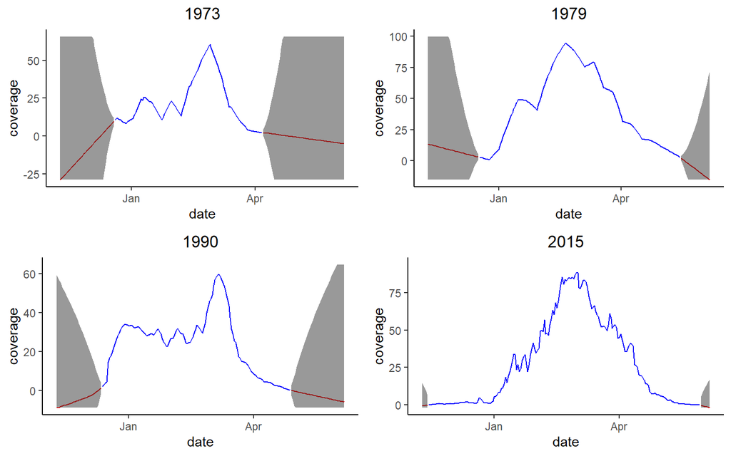

Figure 3.3: Forecastd Imputed Values with Confidence Bands

The year 1979 is particularly peculiar in figure 3.3 as the leading missing values actually increased as the forecast went back in time. Although this is not a feasible occurrence in reality, this does not pose an issue to the analysis. This is because despite the back-cast theoretically trending towards infinity, the inverse of the confidence intervals is becoming arbitrarily small as they approach zero. So these values are essentially “zeroed out” in the analysis.

To capture the impressiveness of increases in ice coverage at high percentages, the weighted sum of the ratio of the percent of the lake covered in ice to the percentage not covered in ice was calculated for each year. Figure 3.4 **(A)** displays the the time series of this metric over the recorded years. An overall, negative trend appears evident. Also, the years that were most extreme in terms of having increases of high percentages of ice coverage are further separated from other years with respect to the weighted sum of the ice coverage ratios. In Figure 3.4 **(A)**, 1996 is distinctly lower than 1994, an observation not captured in simple cumulative metrics. Indeed, observing figure 3.5 **(C)** and **(D)** shows that while these two years follow similar trends, the peaks in 1996 are fluctuating, while the similar peaks in 1994 are more consistent. Hence, both the magnitude and length of peaks are emphasized here, and consistent ice coverage is more properly rewarded rather than periods of rapid freezing and melting.

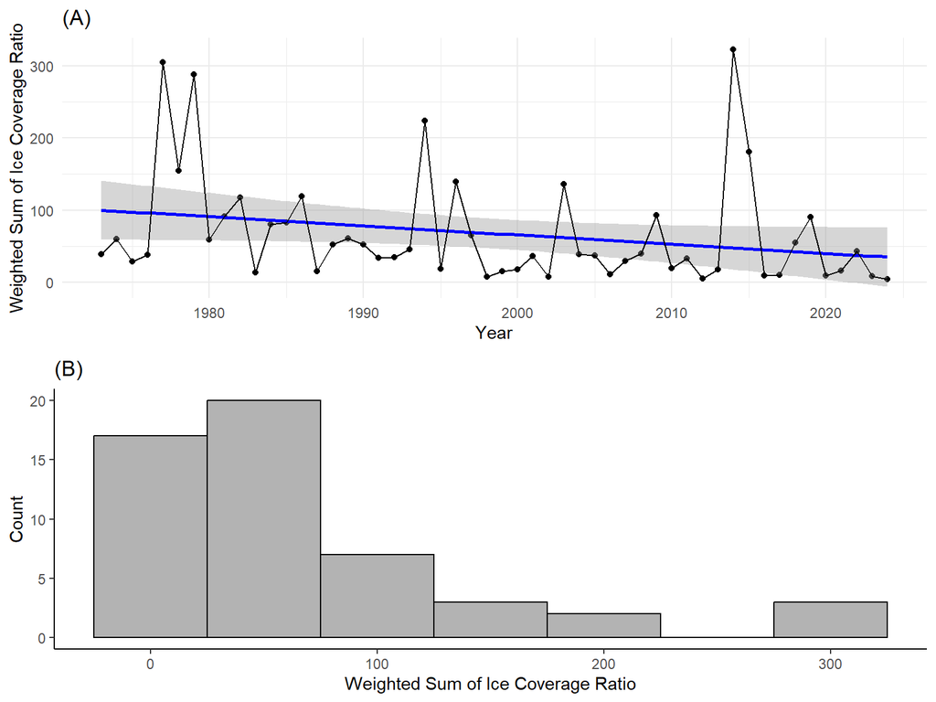

Figure 3.4: Time Series and Distribution of the Yearly Weighted Cumulative Ice Cover Ratios

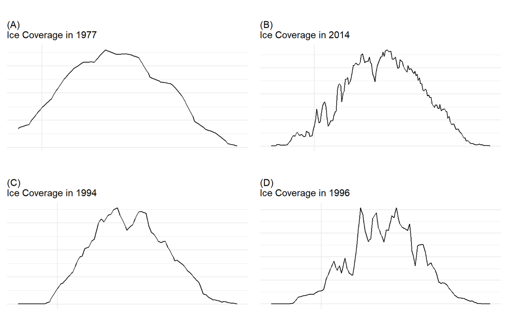

Figure 3.5: Daily Ice Coverage for years 1977, 1994, 1996 and 2014

## 3.2 Results of Theil-Sen Estimation

Prior to fitting a linear model via Theil-Sen estimation, it was necessary to assess the presence of autocorrelation in the data. After aggregating the weighted cumulative mass of ice cover ratios to the yearly level, the autocorrelation was assessed. The estimated autocorrelation and partial autocorrelation functions displayed in figure 3.6 show no evidence of autocorrelation at any lag in years. Thus, further modeling assumed no need to account for autocorrelation. It is likely the case that between each year of measurements, there exists a *reset* period from June 6 to November 9 where the ice cover is assumed to be negligible, and thus every year starts and ends at zero and this separation makes the annually aggregated measurements independent. Additionally, aggregating from a daily level to a yearly measurement may have “smoothed out” autocorrelation evident at short intervals, such as daily fluctuations in ice coverage.

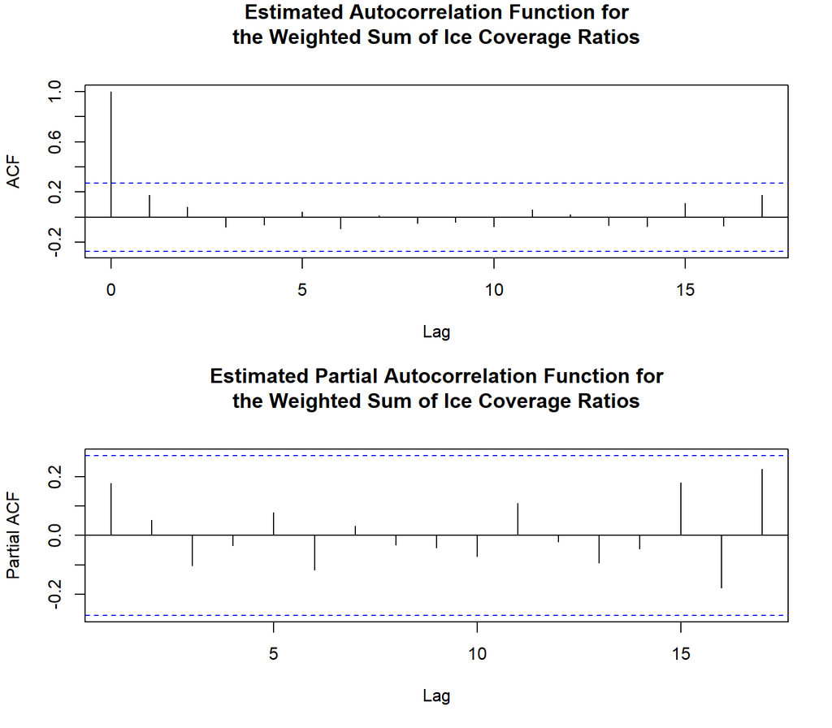

Figure 3.6: Correlogram and Partial Correlogram of Weighted Sum of Ice Coverage Ratios

Next, the assessment of the overall trend of the weighted sum of ice coverage ratios over the years was done by fitting a Theil-Sen single median linear model. Table 3.2 includes the Theil-Sen estimate of both the intercept and the slope of the robustly fitting line. The intercept is meaningless in this application as a Year of zero is irrelevant to ice coverage trends in the past 52 years. However, the estimated slope is about -0.966. 0.966 (which is about 1) can be interpreted as the decrease in the average weighted sum of ice coverage ratios between each year. Additionally, table 3.2 shows the 95% confidence interval for the slope estimate. The interval being entirely negative indicates statistically significant evidence of a negative trend in the weighted sum of ice coverage ratios.

Table 3.2: Theil-Sen Slope and Intercept Estimate and accompanying 95% Confidence Intervals

|  | Estimate | Lower 95% | Upper 95% |
| --- | --- | --- | --- |
| Intercept | 1971.433 | 1967.010 | 2000.895 |
| Year | -0.966 | -1.428 | -0.883 |

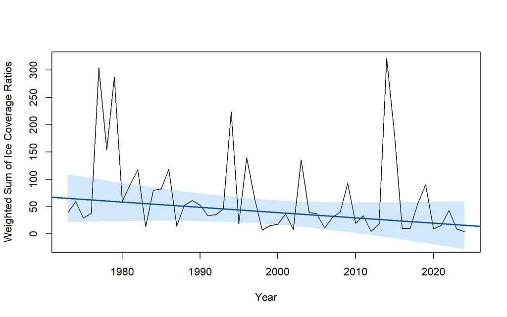

Figure 3.7: Estimated Single Median Slope

# 4 Conclusion

This concludes our comprehensive analysis of ice coverage in the Great Lakes from 1973-2024, which includes the description of important long-term trends that have occurred. As section 3.2 indicates, there is a statistically significant decrease in the weighted sum of ice coverage ratios over the past 52 years. In more layman’s terms, there is clear decline in ice coverage in the Great Lakes. We can conclude, as a result of the nature of our chosen metric, that more recent years have less often reached higher levels of ice coverage and been less able to sustain any high levels of ice coverage. This downward trend can have significant environmental impacts, especially if it continues in the same direction. Natural ecosystems, greenhouse gas emissions, and climate patterns may all see negative effects as a result (if not already realized). In addition to these adverse effects, the result of this analysis can also serve as an indication of other natural phenomena taking place. It is most likely that North America is not sustaining levels of cold for long enough during the winter months to achieve and keep ice coverage levels more common in years past. This is purely speculation and not a finding of this analysis, but it matches what many environmental specialists are saying on the topic.

The analysis in this report certainly has limitations that warrant addressing. The amount of missing values that were present in this data set has been precisely laid out. The nature of data sets that contain lots of missing information typically require a caveat when an analysis is performed. In the case of this report, missing values were imputed via forecasting. Although this method used sophisticated processes to fill these missing observations and account for their uncertainty, the true values remain unknown. Abnormal weather events could have occurred, throwing off our assumptions of a more gradual increase and decrease from and to 0% respectively in each year. Even if our assumption is apt for most years, the exactness of these imputations are still not perfect compared to an observed value. To reiterate, the methods in this analysis did weigh these observations by their amount of uncertainty, but the point still remains.

Another possible caveat has to do with the modeling of the natural system in which the data originates. Although no evidence of autocorrelation in the weighted sum of ice coverage ratios over the years was found (leading to the omission of a time series analysis), there still may be some shifts in the environment over time that should have been accounted for. Additionally, despite our reasoning for opting to use the weighted sum of ice coverage ratios to determine ice coverage trends in the Great Lakes, the interpretability of the results is not as desirable as other (less nuanced) metrics. Regardless, the takeaways from the analysis still hold true and may serve as a guide for future environmental concern efforts.

# References

Auguie, Baptiste. 2017. “gridExtra: Miscellaneous Functions for "Grid" Graphics.”

Barnier, Julien. 2022. “Rmdformats: HTML Output Formats and Templates for ’Rmarkdown’ Documents.” https://github.com/juba/rmdformats.

Beeton, Alfred M. 2024. “Great Lakes.” Encyclopedia Britannica. https://www.britannica.com/place/Great-Lakes.

Graham, Lester. 2024. “Consequences of Less Ice on Lakes Due to Climate Change.” Great Lakes Now. https://www.greatlakesnow.org/2024/10/consequences-of-less-ice-on-lakes-due-to-climate-change/#:~:text=Open%20water%20contributes%20to%20lake,reproduce%2C%20such%20as%20whitefish.

Hyndman, Rob, George Athanasopoulos, Christoph Bergmeir, Gabriel Caceres, Leanne Chhay, Mitchell O’Hara-Wild, Fotios Petropoulos, Slava Razbash, Earo Wang, and Farah Yasmeen. 2024. “Forecast: Forecasting Functions for Time Series and Linear Models.” https://pkg.robjhyndman.com/forecast/.

Komsta, Lukasz. 2019. *Mblm: Median-Based Linear Models*. https://www.r-project.org.

R Core Team. 2024. *R: A Language and Environment for Statistical Computing*. Vienna, Austria: R Foundation for Statistical Computing. https://www.R-project.org/.

Wickham, Hadley, Mara Averick, Jennifer Bryan, Winston Chang, Lucy D’Agostino McGowan, Romain François, Garrett Grolemund, et al. 2019. “Welcome to the Tidyverse” 4: 1686. https://doi.org/10.21105/joss.01686.

Wikipedia contributors. 2024. “Theil–Sen Estimator.” Wikipedia. https://en.m.wikipedia.org/wiki/Theil%E2%80%93Sen_estimator.

Xie, Yihui. 2024. “Knitr: A General-Purpose Package for Dynamic Report Generation in r.” https://yihui.org/knitr/.

Zhu, Hao. 2024. “kableExtra: Construct Complex Table with ’Kable’ and Pipe Syntax.” http://haozhu233.github.io/kableExtra/.

[^1]: fannonre@miamioh.edu
[^2]: smith660@miamioh.edu